# Objectifs :

- Extraire des infos intéressantes type :
  - prix min, moyen et max
  - durée min, max, moyenne par trajet
- Différence de prix moyen et durée selon le train, le bus et le covoit selon la distance du trajet

  Par exemple (0-200km, 201-800km, 800-2000km, 2000+km)
- Le plus d’infos bonus !

  Comme par exemple :

  *Graphes, prédictions de prix, rapport des soucis relevés dans les données, visualisation interactive, sourcing & utilisation de données externes pertinentes, utilisation d’API externes*

# Info utiles sur les fichiers CSV :

- *ticket_data.csv* : Contenant un historique de ticket (une ligne => une proposition de ticket sur tictactrip)
- *cities.csv* les villes desservies par tictactrip (lien grâce aux colonnes o_city (origin_city), d_city (destination_city) de ticket_data)
- *stations.csv* les stations desservies par tictactrip (lien via o_station, d_station de ticket_data)
- *providers.csv* infos sur les différents providers (lien via company de ticket_data)Un provider est une "sous-compagnie". Par exemple TGV et TER sont deux providers de VSC (voyages-sncf).

### 1- Import

```python
%load_ext autoreload
%autoreload 2
import seaborn as sns
import pandas as pd
import matplotlib.pyplot as plt
import numpy as np

from sklearn.tree import DecisionTreeRegressor
from sklearn.ensemble import RandomForestRegressor
from sklearn.linear_model import LinearRegression, Ridge, Lasso
from sklearn import metrics
from sklearn.model_selection import cross_validate, GridSearchCV, KFold

from process import *
```

```
The autoreload extension is already loaded. To reload it, use:
  %reload_ext autoreload
```

### 2- Fouille de données

```python
TICKET_FILE = '../data/raw/ticket_data.csv'
PROVIDERS_FILE = '../data/raw/providers.csv'
STATIONS_FILE = '../data/raw/stations.csv'
CITIES_FILE = '../data/raw/cities.csv'
df = pd.read_csv(TICKET_FILE)
df_providers = pd.read_csv(PROVIDERS_FILE)
df_stations = pd.read_csv(STATIONS_FILE)
df_cities = pd.read_csv(CITIES_FILE)
```

```python
df.shape
```

```
(74168, 12)
```

```python
df.head(10)
```

|  | id | company | o_station | d_station | departure_ts | arrival_ts | price_in_cents | search_ts | middle_stations | other_companies | o_city | d_city |
| --- | --- | --- | --- | --- | --- | --- | --- | --- | --- | --- | --- | --- |
| 0 | 6795025 | 8385 | NaN | NaN | 2017-10-13 14:00:00+00 | 2017-10-13 20:10:00+00 | 4550 | 2017-10-01 00:13:31.327+00 | NaN | NaN | 611 | 542 |
| 1 | 6795026 | 9 | 63.0 | 1044.0 | 2017-10-13 13:05:00+00 | 2017-10-14 06:55:00+00 | 1450 | 2017-10-01 00:13:35.773+00 | {149,418} | {13} | 611 | 542 |
| 2 | 6795027 | 8377 | 5905.0 | 6495.0 | 2017-10-13 13:27:00+00 | 2017-10-14 21:24:00+00 | 7400 | 2017-10-01 00:13:40.212+00 | {798,798,6794,6246} | {8377,8376} | 611 | 542 |
| 3 | 6795028 | 8377 | 5905.0 | 6495.0 | 2017-10-13 13:27:00+00 | 2017-10-14 11:02:00+00 | 13500 | 2017-10-01 00:13:40.213+00 | {798,798,6794,6246} | {8377,8376} | 611 | 542 |
| 4 | 6795029 | 8381 | 5905.0 | 6495.0 | 2017-10-13 21:46:00+00 | 2017-10-14 19:32:00+00 | 7710 | 2017-10-01 00:13:40.213+00 | {5983,5983} | {8380} | 611 | 542 |
| 5 | 6795030 | 8385 | NaN | NaN | 2017-10-06 05:30:00+00 | 2017-10-06 08:30:00+00 | 1800 | 2017-10-01 01:03:18.948+00 | NaN | NaN | 628 | 453 |
| 6 | 6795031 | 8385 | NaN | NaN | 2017-10-06 07:00:42+00 | 2017-10-06 09:30:42+00 | 2150 | 2017-10-01 01:03:18.948+00 | NaN | NaN | 628 | 453 |
| 7 | 6795032 | 8385 | NaN | NaN | 2017-10-06 07:10:00+00 | 2017-10-06 09:40:00+00 | 1700 | 2017-10-01 01:03:18.948+00 | NaN | NaN | 628 | 453 |
| 8 | 6795033 | 8385 | NaN | NaN | 2017-10-06 10:00:00+00 | 2017-10-06 12:50:00+00 | 1700 | 2017-10-01 01:03:18.948+00 | NaN | NaN | 628 | 453 |
| 9 | 6795034 | 8385 | NaN | NaN | 2017-10-06 10:00:00+00 | 2017-10-06 12:50:00+00 | 1900 | 2017-10-01 01:03:18.948+00 | NaN | NaN | 628 | 453 |

```python
len(df[df['arrival_ts'] < df['departure_ts']])
```

```
0
```

```python
df[df['departure_ts'] < df['search_ts']][['id', 'search_ts', 'departure_ts']]
```

|  | id | search_ts | departure_ts |
| --- | --- | --- | --- |
| 54 | 6795260 | 2017-10-01 07:19:44.149+00 | 2017-09-15 09:30:00+00 |
| 222 | 6795246 | 2017-10-01 07:19:44.148+00 | 2017-09-15 00:00:00+00 |
| 223 | 6795247 | 2017-10-01 07:19:44.149+00 | 2017-09-15 07:00:00+00 |
| 224 | 6795248 | 2017-10-01 07:19:44.149+00 | 2017-09-15 07:00:00+00 |
| 225 | 6795249 | 2017-10-01 07:19:44.149+00 | 2017-09-15 07:40:01+00 |
| ... | ... | ... | ... |
| 2668 | 6797693 | 2017-10-02 05:40:59.344+00 | 2017-09-08 17:00:00+00 |
| 24700 | 6819724 | 2017-10-07 17:23:29.619+00 | 2017-10-06 16:40:00+00 |
| 24701 | 6819725 | 2017-10-07 17:23:29.619+00 | 2017-10-06 17:20:00+00 |
| 24702 | 6819726 | 2017-10-07 17:23:29.619+00 | 2017-10-06 19:50:00+00 |
| 24703 | 6819727 | 2017-10-07 17:23:29.619+00 | 2017-10-06 17:40:00+00 |

258 rows × 3 columns

Le service propose des tickets dont la date de départ est antérieur à celle de la date de la recherche.

```python
df.dtypes
```

```
id                   int64
company              int64
o_station          float64
d_station          float64
departure_ts        object
arrival_ts          object
price_in_cents       int64
search_ts           object
middle_stations     object
other_companies     object
o_city               int64
d_city               int64
dtype: object
```

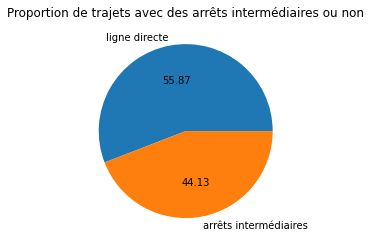

```python
df_middle_stations = pd.DataFrame()
df_middle_stations['middle_stations'] = df['middle_stations'].copy()

df_middle_stations['middle_stations'] = df_middle_stations['middle_stations'].where(df_middle_stations['middle_stations'].isna(), "arrêts intermédiaires")
df_middle_stations['middle_stations'] = df_middle_stations['middle_stations'].where(df_middle_stations['middle_stations'].notna(), "ligne directe")
df_middle_stations["middle_stations"].value_counts().plot(kind='pie'
                                        , title="Proportion de trajets avec des arrêts intermédiaires ou non"
                                        , ylabel=''
                                        , xlabel=''
                                        , autopct='%.2f')
plt.show()
```

```python
df_copy = df[df['departure_ts'] > df['search_ts']].copy()
df_copy['search_ts'] = pd.to_datetime (df_copy['search_ts'])
df_copy['departure_ts'] = pd.to_datetime (df_copy['departure_ts'])
df_copy['arrival_ts'] = pd.to_datetime (df_copy['arrival_ts'])

df_copy = df_copy.sort_values(by='search_ts')

df_copy[['id', 'search_ts', 'departure_ts', 'arrival_ts']].head(5)
```

|  | id | search_ts | departure_ts | arrival_ts |
| --- | --- | --- | --- | --- |
| 0 | 6795025 | 2017-10-01 00:13:31.327000+00:00 | 2017-10-13 14:00:00+00:00 | 2017-10-13 20:10:00+00:00 |
| 1 | 6795026 | 2017-10-01 00:13:35.773000+00:00 | 2017-10-13 13:05:00+00:00 | 2017-10-14 06:55:00+00:00 |
| 2 | 6795027 | 2017-10-01 00:13:40.212000+00:00 | 2017-10-13 13:27:00+00:00 | 2017-10-14 21:24:00+00:00 |
| 3 | 6795028 | 2017-10-01 00:13:40.213000+00:00 | 2017-10-13 13:27:00+00:00 | 2017-10-14 11:02:00+00:00 |
| 4 | 6795029 | 2017-10-01 00:13:40.213000+00:00 | 2017-10-13 21:46:00+00:00 | 2017-10-14 19:32:00+00:00 |

```python
df_copy[['id', 'search_ts', 'departure_ts', 'arrival_ts']].tail(5)
```

|  | id | search_ts | departure_ts | arrival_ts |
| --- | --- | --- | --- | --- |
| 74159 | 6869186 | 2017-10-19 10:35:42.943000+00:00 | 2017-10-27 08:30:00+00:00 | 2017-10-27 16:00:00+00:00 |
| 74158 | 6869184 | 2017-10-19 10:35:42.943000+00:00 | 2017-10-27 07:00:00+00:00 | 2017-10-27 16:00:00+00:00 |
| 74157 | 6869183 | 2017-10-19 10:35:42.943000+00:00 | 2017-10-27 07:00:00+00:00 | 2017-10-27 21:10:00+00:00 |
| 74161 | 6869190 | 2017-10-19 10:35:42.943000+00:00 | 2017-10-27 14:00:00+00:00 | 2017-10-27 21:15:00+00:00 |
| 74167 | 6869191 | 2017-10-19 10:35:42.943000+00:00 | 2017-10-27 14:45:00+00:00 | 2017-10-27 21:40:00+00:00 |

```python
df_copy['time_difference'] = df_copy['search_ts'].diff().dt.total_seconds()
print(df_copy['time_difference'].describe())
```

```
count    73909.000000
mean        21.547195
std        295.506649
min          0.000000
25%          0.000000
50%          0.000000
75%          0.000000
max      27078.821000
Name: time_difference, dtype: float64
```

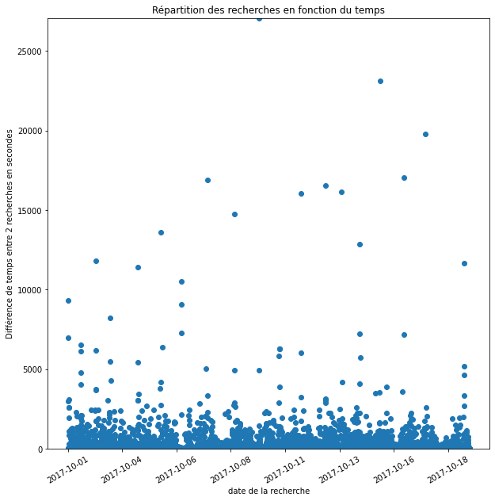

```python
df_plot = df_copy.set_index(df_copy['search_ts'].map(lambda s: s.strftime('%Y-%m-%d')))
fig, ax=plt.subplots(figsize=(10,10))
df_plot['time_difference'].plot(marker="o"
                                , linewidth=0
                                , x='search_ts'
                                , ylim=[0, df_copy['time_difference'].max()]
                                ,rot=30)

ax.set_ylabel("Différence de temps entre 2 recherches en secondes")
ax.set_xlabel("date de la recherche")
ax.set_title("Répartition des recherches en fonction du temps")
plt.show()
```

```python
df_copy['travel_time'] = (df_copy['arrival_ts'] - df_copy['departure_ts']).dt.total_seconds() / 3600
print(df_copy['travel_time'].describe())
```

```
count    73910.000000
mean         7.088751
std          9.931288
min          0.333333
25%          3.000000
50%          4.833333
75%          8.000000
max        492.850000
Name: travel_time, dtype: float64
```

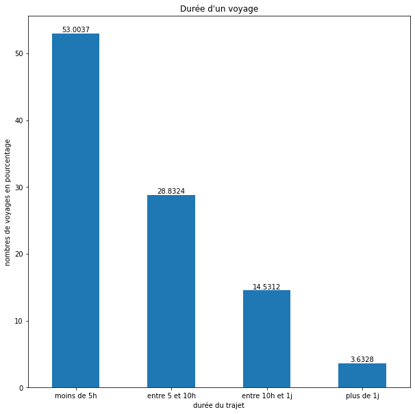

```python
out = pd.cut(df_copy['travel_time']
            , bins=[0, 5, 10, 24, 1000]
            , include_lowest=True
            , labels=['moins de 5h', 'entre 5 et 10h', 'entre 10h et 1j', 'plus de 1j'])
out_norm = out.value_counts(sort=False, normalize=True) * 100

ax = out_norm.plot(kind='bar'
                , rot=0
                , figsize=(10,10))
ax.set_ylabel("nombres de voyages en pourcentage")
ax.set_xlabel("durée du trajet")
ax.set_title("Durée d'un voyage")
ax.bar_label(ax.containers[0])
plt.show()
```

```python
df_copy['price_in_cents'].describe()
```

```
count    73910.000000
mean      4389.159302
std       3743.829568
min        300.000000
25%       1900.000000
50%       3350.000000
75%       5250.000000
max      38550.000000
Name: price_in_cents, dtype: float64
```

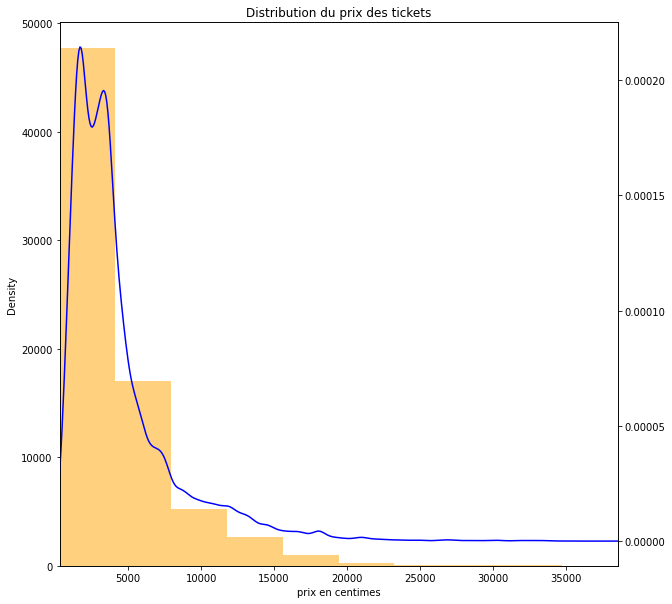

```python
fig, ax = plt.subplots(figsize=(10,10))
ax = df['price_in_cents'].plot(kind='hist'
                            , color='orange'
                            , alpha=0.5)
df['price_in_cents'].plot(kind='kde'
                            , title='Distribution du prix des tickets'
                            , ax=ax
                            , secondary_y=True
                            , color='blue'
                            , xlim=[df['price_in_cents'].min(), df['price_in_cents'].max()])
ax.set_xlabel("prix en centimes")

plt.show()
```

```python
companies = df_providers.query('provider_id.isnull()')[['company_id', 'fullname']]
df_companies = df_copy.apply(lambda x :get_company_name (x, df_providers, companies), axis=1)
```

```python
df_group_count_companies = df_companies.groupby(['company', 'id'], as_index=False).count()
```

```python
df_group_count_companies.company.value_counts()
```

```
Blablacar         41183
Voyages SNCF      19099
Flixbus            7433
Ouibus             3560
Transdev           2332
Distribusion        273
Vatry                16
Deinbus.de            9
Student Agency        5
Name: company, dtype: int64
```

Blablacar est la compagnie qui propose le plus de tickets.

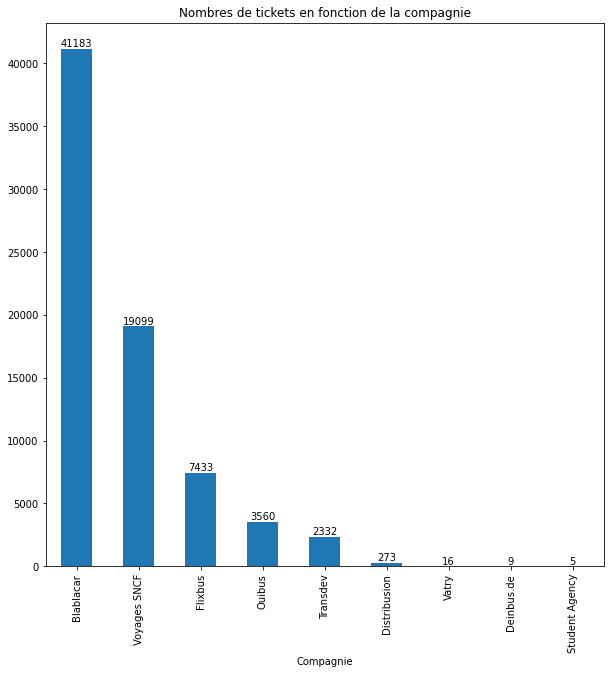

```python
ax = df_group_count_companies.company.value_counts().plot(kind='bar'
                                            , title='Nombres de tickets en fonction de la compagnie'
                                            , figsize=(10,10))
ax.set_xlabel('Compagnie')
ax.bar_label(ax.containers[0])
plt.show()
```

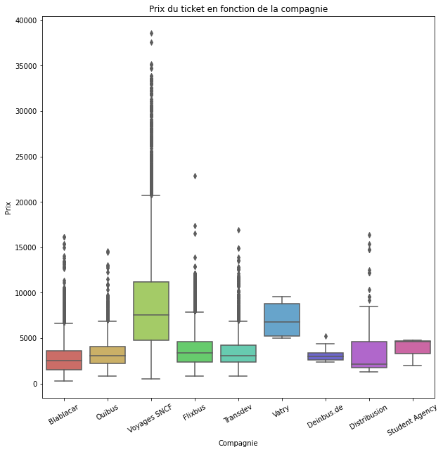

```python
plt.figure(figsize=(10,10))
ax = sns.boxplot(x=df_companies['company']
                , y=df_companies['price_in_cents']
                , palette='hls')

ax.set_xticklabels(ax.get_xticklabels()
                , rotation=30)

plt.title('Prix du ticket en fonction de la compagnie')
plt.xlabel('Compagnie')
plt.ylabel('Prix')
plt.show()
```

Blablacar et Distribusion proposent les trajets les moins chers.  
Voyages SNCF propose les prix les plus chers.

```python
df_copy = df_copy.apply(count_number_middle_stations, axis=1)
```

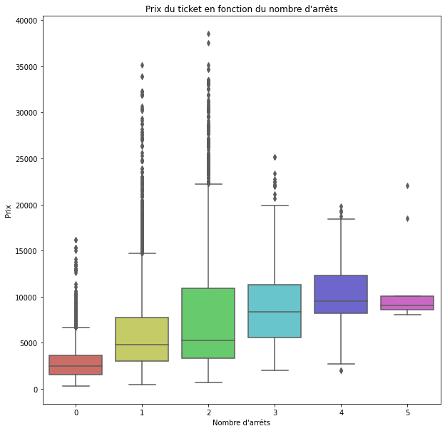

```python
plt.figure(figsize=(10,10))
ax = sns.boxplot(x=df_copy['number_middle_stations']
                , y=df_companies['price_in_cents']
                , palette='hls')

plt.title("Prix du ticket en fonction du nombre d'arrêts")
plt.xlabel("Nombre d'arrêts")
plt.ylabel('Prix')
plt.show()
```

Les trajets avec 4 arrêts sont les plus chers.  
Les trajets sans arrêts sont les moins chers.

```python
df_copy['days_left'] = (df_copy['departure_ts'] - df_copy['search_ts']).astype('timedelta64[D]')
print(df_copy['days_left'].describe())
```

```
count    73910.000000
mean         6.800690
std         10.515275
min          0.000000
25%          1.000000
50%          4.000000
75%          8.000000
max        176.000000
Name: days_left, dtype: float64
```

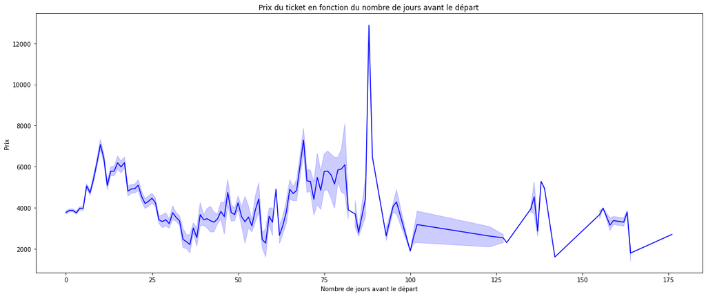

```python
plt.figure(figsize=(20,8))
sns.lineplot(data=df_copy,x='days_left',y='price_in_cents',color='blue')
plt.title('Prix du ticket en fonction du nombre de jours avant le départ')
plt.xlabel('Nombre de jours avant le départ')
plt.ylabel('Prix')
plt.show()
```

```python
bins_distance = [0, 200, 800, 2000, 10000]
```

```python
df_copy = df_copy.apply(lambda x: get_time_of_day(x, 'departure_ts'), axis=1)
df_copy = df_copy.apply(lambda x: get_time_of_day(x, 'arrival_ts'), axis=1)
```

```python
df_copy = df_copy.apply(lambda x: get_distance_between_cities(x, df_cities), axis=1)
```

```python
df_copy = df_copy.apply(lambda x: get_info_providers(x, df_providers), axis=1)
```

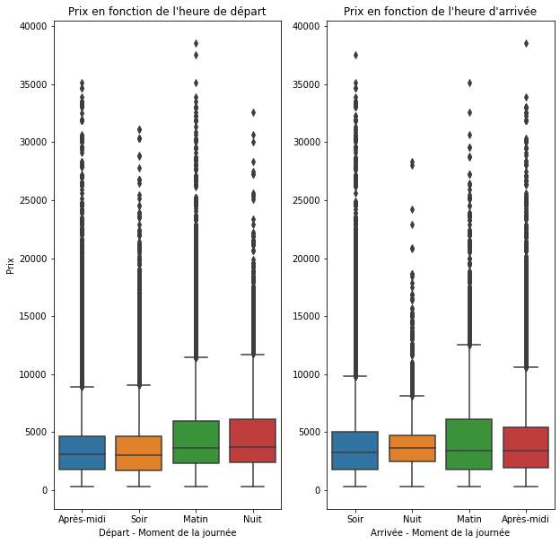

```python
plt.figure(figsize=(10,10))
plt.subplot(1,2,1)
sns.boxplot(x='departure_ts_time_of_day',y='price_in_cents',data=df_copy)
plt.title("Prix en fonction de l'heure de départ")
plt.xlabel('Départ - Moment de la journée')
plt.ylabel('Prix')

plt.subplot(1,2,2)
sns.boxplot(x='arrival_ts_time_of_day',y='price_in_cents',data=df_copy)
plt.title("Prix en fonction de l'heure d'arrivée")
plt.xlabel('Arrivée - Moment de la journée')
plt.ylabel('')
plt.show()
```

Le prix du trajet est plus cher quand on souhaite partir la nuit.  
Le prix du trajet est le moins cher quand on souhaite partir l'après-midi ou le soir.  
Le prix du trajet à tendance à être plus élevé quand on souhaite arriver le matin.  
Le prix du trajet à tendance à être légèrement moins cher quand on souhaite arriver le soir.

```python
df_transport_mean_price = df_copy.groupby (by=['transport_type', pd.cut(df_copy['distance'], bins_distance, labels=['0-200km', '200-800km', '800-2000km', '2000km+'])])['price_in_cents'].mean()
df_transport_mean_price.unstack()
```

| distance transport_type | 0-200km | 200-800km | 800-2000km | 2000km+ |
| --- | --- | --- | --- | --- |
| bus | 2182.830918 | 3494.850022 | 6949.950045 | NaN |
| carpooling | 1176.185000 | 3221.437776 | 8631.661972 | NaN |
| train | 3487.900779 | 9124.779489 | 15463.746130 | NaN |

```python
df_transport_mean_travel_time = df_copy.groupby (by=['transport_type', pd.cut(df_copy['distance'], bins_distance, labels=['0-200km', '200-800km', '800-2000km', '2000km+'])])['travel_time'].mean()
df_transport_mean_travel_time.unstack()
```

| distance transport_type | 0-200km | 200-800km | 800-2000km | 2000km+ |
| --- | --- | --- | --- | --- |
| bus | 10.232515 | 15.074797 | 27.536119 | NaN |
| carpooling | 1.950333 | 4.768698 | 13.116197 | NaN |
| train | 4.419400 | 7.677651 | 12.158617 | NaN |

```python
df_copy['has_wifi'] = df_copy['has_wifi'].replace ({True:1, False:0})
df_copy['has_plug'] = df_copy['has_plug'].replace ({True:1, False:0})
df_copy['has_adjustable_seats'] = df_copy['has_adjustable_seats'].replace ({True:1, False:0})
df_copy['has_bicycle'] = df_copy['has_bicycle'].replace ({True:1, False:0})
```

```python
df_dummies_transport = pd.get_dummies(df_copy['transport_type'])
df_corr = pd.concat([df_copy, df_dummies_transport], axis=1)
del df_corr['transport_type']
```

```python
df_corr.corr()
```

|  | id | company | o_station | d_station | price_in_cents | o_city | d_city | time_difference | travel_time | number_middle_stations | days_left | distance | has_wifi | has_plug | has_adjustable_seats | has_bicycle | bus | carpooling | train |
| --- | --- | --- | --- | --- | --- | --- | --- | --- | --- | --- | --- | --- | --- | --- | --- | --- | --- | --- | --- |
| id | 1.000000 | 0.003425 | -0.001150 | 0.091369 | 0.132466 | -0.076435 | 0.047500 | -0.008282 | 0.076002 | 0.091048 | 0.014722 | 0.072670 | -0.009535 | -0.001074 | 0.108637 | 0.010443 | -0.002584 | -0.103465 | 0.120050 |
| company | 0.003425 | 1.000000 | 0.358219 | 0.222512 | 0.086823 | 0.062758 | 0.011667 | -0.003351 | -0.319454 | -0.416620 | -0.315955 | -0.230595 | -0.874370 | -0.366600 | 0.009497 | 0.044348 | -0.886102 | 0.477046 | 0.248168 |
| o_station | -0.001150 | 0.358219 | 1.000000 | 0.037815 | 0.094369 | 0.204974 | 0.004098 | -0.017379 | -0.067560 | -0.059518 | -0.098045 | -0.093554 | -0.305585 | -0.044311 | 0.333555 | -0.080669 | -0.236470 | NaN | 0.236470 |
| d_station | 0.091369 | 0.222512 | 0.037815 | 1.000000 | 0.089860 | 0.038798 | 0.330545 | 0.000782 | -0.020878 | -0.014708 | -0.036704 | -0.028775 | -0.248652 | -0.119961 | 0.186901 | -0.055978 | -0.225460 | NaN | 0.225460 |
| price_in_cents | 0.132466 | 0.086823 | 0.094369 | 0.089860 | 1.000000 | 0.000766 | -0.011596 | -0.008769 | 0.158632 | 0.503589 | 0.077616 | 0.543426 | -0.020360 | 0.033271 | 0.495334 | 0.293237 | -0.094278 | -0.493107 | 0.645320 |
| o_city | -0.076435 | 0.062758 | 0.204974 | 0.038798 | 0.000766 | 1.000000 | 0.026361 | 0.010629 | -0.005260 | 0.015111 | -0.028231 | -0.027791 | -0.072010 | -0.052416 | 0.025249 | -0.009767 | -0.059411 | 0.004715 | 0.047673 |
| d_city | 0.047500 | 0.011667 | 0.004098 | 0.330545 | -0.011596 | 0.026361 | 1.000000 | 0.015488 | 0.032731 | 0.022628 | 0.011752 | -0.023932 | -0.040487 | -0.022995 | 0.038611 | -0.022035 | -0.006050 | -0.034693 | 0.044882 |
| time_difference | -0.008282 | -0.003351 | -0.017379 | 0.000782 | -0.008769 | 0.010629 | 0.015488 | 1.000000 | 0.020752 | -0.020572 | 0.037401 | 0.018268 | 0.003578 | -0.002524 | -0.029780 | -0.007059 | 0.006283 | 0.025223 | -0.034313 |
| travel_time | 0.076002 | -0.319454 | -0.067560 | -0.020878 | 0.158632 | -0.005260 | 0.032731 | 0.020752 | 1.000000 | 0.334406 | 0.266475 | 0.393394 | 0.360388 | 0.220202 | 0.188432 | -0.014971 | 0.412204 | -0.336110 | 0.014507 |
| number_middle_stations | 0.091048 | -0.416620 | -0.059518 | -0.014708 | 0.503589 | 0.015111 | 0.022628 | -0.020572 | 0.334406 | 1.000000 | 0.250610 | 0.342870 | 0.472886 | 0.330532 | 0.699477 | 0.135559 | 0.474535 | -0.882682 | 0.580861 |
| days_left | 0.014722 | -0.315955 | -0.098045 | -0.036704 | 0.077616 | -0.028231 | 0.011752 | 0.037401 | 0.266475 | 0.250610 | 1.000000 | 0.252008 | 0.345284 | 0.190445 | 0.108701 | -0.007367 | 0.369029 | -0.268113 | -0.024330 |
| distance | 0.072670 | -0.230595 | -0.093554 | -0.028775 | 0.543426 | -0.027791 | -0.023932 | 0.018268 | 0.393394 | 0.342870 | 0.252008 | 1.000000 | 0.257745 | 0.138881 | 0.205835 | 0.040066 | 0.272951 | -0.324929 | 0.126098 |
| has_wifi | -0.009535 | -0.874370 | -0.305585 | -0.248652 | -0.020360 | -0.072010 | -0.040487 | 0.003578 | 0.360388 | 0.472886 | 0.345284 | 0.257745 | 1.000000 | 0.629624 | 0.058444 | 0.221762 | 0.910963 | -0.527994 | -0.212090 |
| has_plug | -0.001074 | -0.366600 | -0.044311 | -0.119961 | 0.033271 | -0.052416 | -0.022995 | -0.002524 | 0.220202 | 0.330532 | 0.190445 | 0.138881 | 0.629624 | 1.000000 | 0.340350 | 0.352213 | 0.517225 | -0.332438 | -0.083263 |
| has_adjustable_seats | 0.108637 | 0.009497 | 0.333555 | 0.186901 | 0.495334 | 0.025249 | 0.038611 | -0.029780 | 0.188432 | 0.699477 | 0.108701 | 0.205835 | 0.058444 | 0.340350 | 1.000000 | -0.072810 | 0.114708 | -0.782891 | 0.788482 |
| has_bicycle | 0.010443 | 0.044348 | -0.080669 | -0.055978 | 0.293237 | -0.009767 | -0.022035 | -0.007059 | -0.014971 | 0.135559 | -0.007367 | 0.040066 | 0.221762 | 0.352213 | -0.072810 | 1.000000 | -0.049967 | -0.117089 | 0.177821 |
| bus | -0.002584 | -0.886102 | -0.236470 | -0.225460 | -0.094278 | -0.059411 | -0.006050 | 0.006283 | 0.412204 | 0.474535 | 0.369029 | 0.272951 | 0.910963 | 0.517225 | 0.114708 | -0.049967 | 1.000000 | -0.537444 | -0.281116 |
| carpooling | -0.103465 | 0.477046 | NaN | NaN | -0.493107 | 0.004715 | -0.034693 | 0.025223 | -0.336110 | -0.882682 | -0.268113 | -0.324929 | -0.527994 | -0.332438 | -0.782891 | -0.117089 | -0.537444 | 1.000000 | -0.658208 |
| train | 0.120050 | 0.248168 | 0.236470 | 0.225460 | 0.645320 | 0.047673 | 0.044882 | -0.034313 | 0.014507 | 0.580861 | -0.024330 | 0.126098 | -0.212090 | -0.083263 | 0.788482 | 0.177821 | -0.281116 | -0.658208 | 1.000000 |

Nous allons conserver les colonnes qui possèdent une corrélation supérieure à 0.15 (en valeur absolue). Les colonnes conservées sont donc :

- travel_time
- distance
- has_adjustable_seats
- has_bicycle
- carpooling
- train
- number_middle_stations

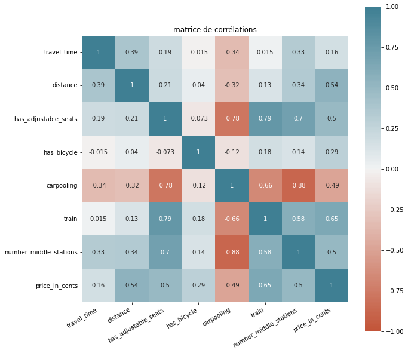

```python
df_to_plot = df_corr[['travel_time', 'distance', 'has_adjustable_seats', 'has_bicycle', 'carpooling', 'train', 'number_middle_stations', 'price_in_cents']]
fig, ax = plt.subplots(figsize=(10,10))
ax = sns.heatmap(df_to_plot.corr()
                , vmin=-1, vmax=1, center=0
                , cmap=sns.diverging_palette(20, 220, n=200)
                , square=True
                , annot=True
)
ax.set_xticklabels(ax.get_xticklabels()
                , rotation=30
                , horizontalalignment='right')
ax.set_title ("matrice de corrélations");
```

La matrice des corrélations affiche des valeurs (corrélations) comprise entre -1 et 1. Lorsque la valeur est proche de +-1, les 2 variables sont dites fortement corrélées. Si la valeur est proche de 0 alors les 2 variables ne sont pas corrélées.  
Pour la ligne du prix on peut lire par exemple :

- Lorsque la distance du trajet augmente alors le prix du trajet a tendance à monter.
- Lorsqu'il y a un rangement pour vélo alors le prix du trajet a tendance à monter.
- Lorsque le type de trajet est "carpooling" alors le prix du trajet a tendance à diminuer.

### Analyses

- id : numéro du ticket
- company : société qui propose le service
- o_station : station d'origine desservie
- d_station : station de destination desservie
- departure_ts : date de départ
- arrival_ts : date d'arrivée
- price_in_cents : prix en centimes
- search_ts : date de la recherche (date à laquelle le trajet a été proposé sur l'application)
- middle_stations : stations intermédiaires
- other_companies : autres sociétés
- o_city : ville de départ
- d_city : ville d'arrivée

o_city et d_city correspondent respectivement au point de départ et au point d'arrivée d'un trajet (de A -> B). On peut retrouver des infos sur ces points dans le fichier cities.  
o_station et d_stations correspondent aux stations desservies. On peut retrouver sdes infos sur ces stations dans le fichier stations.  
On remarque des valeurs NaN sur 4 colonnes : o_station, d_station, middle_stations, other_companies.  
Ces 4 colonnes sont corrélées à la société de transport. En effet, on remarque que lorsque la société propose des voitures en tant que moyen de transport (ligne 0), les 4 colonnes semblent avoir la valeur NaN.  
De même, lorsque la société propose un train en tant que moyen de transport (ligne 2), les 4 colonnes semblent avoir des valeurs.  
Cette observation parait logique puisque un voyage en train a pour habitude d'avoir des arrêts (sauf train direct) alors que faire du covoiturage limite les chances d'avoir des arrêts intermédiaires.

### Data Preparation

```python
df_regression = df_corr[['travel_time', 'distance', 'has_adjustable_seats', 'has_bicycle', 'carpooling', 'train', 'price_in_cents']]
df_regression = df_regression.fillna(0)
```

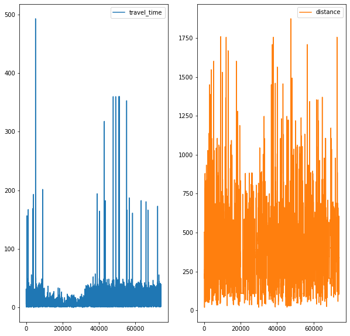

```python
df_regression[['travel_time', 'distance']].plot(subplots=True, layout=(1,2), figsize=(10,10))
plt.show()
```

```python
df_regression
```

|  | travel_time | distance | has_adjustable_seats | has_bicycle | carpooling | train | price_in_cents |
| --- | --- | --- | --- | --- | --- | --- | --- |
| 0 | 6.166667 | 503.136831 | 0.0 | 0.0 | 1 | 0 | 4550 |
| 1 | 17.833333 | 503.136831 | 1.0 | 0.0 | 0 | 0 | 1450 |
| 2 | 31.950000 | 503.136831 | 1.0 | 0.0 | 0 | 1 | 7400 |
| 3 | 21.583333 | 503.136831 | 1.0 | 0.0 | 0 | 1 | 13500 |
| 4 | 21.766667 | 503.136831 | 1.0 | 0.0 | 0 | 1 | 7710 |
| ... | ... | ... | ... | ... | ... | ... | ... |
| 74159 | 7.500000 | 339.046766 | 1.0 | 0.0 | 0 | 0 | 2400 |
| 74158 | 9.000000 | 339.046766 | 1.0 | 0.0 | 0 | 0 | 2400 |
| 74157 | 14.166667 | 339.046766 | 1.0 | 0.0 | 0 | 0 | 2090 |
| 74161 | 7.250000 | 339.046766 | 1.0 | 0.0 | 0 | 0 | 2700 |
| 74167 | 6.916667 | 339.046766 | 1.0 | 0.0 | 0 | 0 | 2000 |

73910 rows × 7 columns

```python
X_train, X_test, Y_train, Y_test = create_train_test_set(df_regression)
```

```
(59128, 6) (14782, 6)
(59128,) (14782,)
```

### Training

```python
NUMBER_FOLDS = 10
SEED = 42
kfolds = KFold(n_splits=NUMBER_FOLDS, random_state=SEED, shuffle=True)

models= {'LinearRegression' : LinearRegression()
        , 'DecisionTreeRegressor' : DecisionTreeRegressor()
        , 'RandomForestRegressor' : RandomForestRegressor()
        , 'Ridge' : Ridge()
        , 'Lasso' : Lasso()
}
scores = {}
scoring = ['neg_root_mean_squared_error', 'neg_mean_squared_error', 'neg_mean_absolute_error']
for key in models.keys():
        score = cross_validate(models[key], X_train, Y_train, cv=kfolds, scoring=scoring, return_estimator=True)
        scores[key] = score
```

```python
RMSE_values = {}
for key in scores.keys():
    print (key)
    print('Validation Mean Squared Error:', round(scores[key]['test_neg_mean_squared_error'].mean(), 2))
    print("Validation RMSE: ",round(scores[key]['test_neg_root_mean_squared_error'].mean(),2))
    print("Validation MAE: ",round(scores[key]['test_neg_mean_absolute_error'].mean(),2))
    print(' ')
    RMSE_values[key] = round(scores[key]['test_neg_root_mean_squared_error'].mean(),2)

best_model = min(RMSE_values, key=lambda x:abs(0 - RMSE_values[x]))
print (f"Meilleur modèle en comparant le RMSE : {best_model}")
```

```
LinearRegression
Validation Mean Squared Error: -4666947.52
Validation RMSE:  -2158.52
Validation MAE:  -1106.3

DecisionTreeRegressor
Validation Mean Squared Error: -1408333.85
Validation RMSE:  -1185.74
Validation MAE:  -501.86

RandomForestRegressor
Validation Mean Squared Error: -1124323.43
Validation RMSE:  -1059.8
Validation MAE:  -496.55

Ridge
Validation Mean Squared Error: -4666945.06
Validation RMSE:  -2158.52
Validation MAE:  -1106.3

Lasso
Validation Mean Squared Error: -4667051.78
Validation RMSE:  -2158.55
Validation MAE:  -1106.24

Meilleur modèle en comparant le RMSE : RandomForestRegressor
```

```python
parameters_LR = {}

parameters_DTR = {"max_depth" : [1, 3, 5]
                , "min_samples_leaf":[1, 2, 3]
                , "max_leaf_nodes":[None, 10, 20, 30]}

parameters_RFR = {"max_depth" : [1, 3, 5]
                , "min_samples_split" : [2, 4, 6]
                , "min_samples_leaf":[1, 2, 3]}

parameters_Ridge = {'alpha':[200, 230, 250,265, 270, 275, 290, 300, 500]}

parameters_Lasso = {'alpha':[0.02, 0.024, 0.025, 0.026, 0.03]}

parameters = {'LinearRegression' : parameters_LR
        , 'DecisionTreeRegressor' : parameters_DTR
        , 'RandomForestRegressor' : parameters_RFR
        , 'Ridge' : parameters_Ridge
        , 'Lasso' : parameters_Lasso
}

tuning_model = GridSearchCV(models[best_model]
                        , param_grid=parameters[best_model]
                        , scoring=scoring
                        , cv=kfolds
                        , refit='neg_root_mean_squared_error')
tuning_model.fit(X_train, Y_train)
print (tuning_model.best_params_)
```

```
{'max_depth': 5, 'min_samples_leaf': 1, 'min_samples_split': 4}
```

### Evaluation

```python
if best_model == 'LinearRegression':
    tuned_model = LinearRegression(**tuning_model.best_params_)
    model = LinearRegression()
elif best_model == 'DecisionTreeRegressor':
    tuned_model = DecisionTreeRegressor(**tuning_model.best_params_)
    model = DecisionTreeRegressor()
elif best_model == 'RandomForestRegressor':
    tuned_model = RandomForestRegressor(**tuning_model.best_params_)
    model = RandomForestRegressor()
elif best_model == 'Ridge':
    tuned_model = Ridge(**tuning_model.best_params_)
    model = Ridge()
elif best_model == 'Lasso':
    tuned_model = Lasso(**tuning_model.best_params_)
    model = Lasso()

tuned_model.fit(X_train, Y_train)
Y_train_pred = tuned_model.predict(X_train)
Y_test_pred = tuned_model.predict(X_test)

model.fit(X_train, Y_train)
Y_train_pred_2 = model.predict(X_train)
Y_test_pred_2 = model.predict(X_test)
```

```python
print ('Score AVEC hyperparametres: ')
print('Training Mean Squared Error:', round(metrics.mean_squared_error(Y_train,Y_train_pred), 2))
print("Training RMSE: ", round(np.sqrt(metrics.mean_squared_error(Y_train,Y_train_pred)),2))
print("Training MAE: " ,round(metrics.mean_absolute_error(Y_train,Y_train_pred),2))

print(' ')

print('Test Mean Squared Error:', round(metrics.mean_squared_error(Y_test,Y_test_pred), 2))
print("Test RMSE: ", round(np.sqrt(metrics.mean_squared_error(Y_test,Y_test_pred)),2))
print("Test MAE: ", round(metrics.mean_absolute_error(Y_test,Y_test_pred),2))

print(' ')

print ('Score SANS hyperparametres: ')
print('Training Mean Squared Error:', round(metrics.mean_squared_error(Y_train,Y_train_pred_2), 2))
print("Training RMSE: ", round(np.sqrt(metrics.mean_squared_error(Y_train,Y_train_pred_2)),2))
print("Training MAE: " ,round(metrics.mean_absolute_error(Y_train,Y_train_pred_2),2))

print(' ')

print('Test Mean Squared Error:', round(metrics.mean_squared_error(Y_test,Y_test_pred_2), 2))
print("Test RMSE: ", round(np.sqrt(metrics.mean_squared_error(Y_test,Y_test_pred_2)),2))
print("Test MAE: ", round(metrics.mean_absolute_error(Y_test,Y_test_pred_2),2))
```

```
Score AVEC hyperparametres:
Training Mean Squared Error: 3314401.38
Training RMSE:  1820.55
Training MAE:  925.0

Test Mean Squared Error: 3296614.69
Test RMSE:  1815.66
Test MAE:  928.77

Score SANS hyperparametres:
Training Mean Squared Error: 403494.02
Training RMSE:  635.21
Training MAE:  315.7

Test Mean Squared Error: 1089422.61
Test RMSE:  1043.75
Test MAE:  477.84
```

Ces 3 métriques représentent l'erreur moyenne entre la valeur originale et la valeur prédite. Une erreur de 0 signifie que le modèle est parfait.  
Pour sélectionner le modèle, on cherche à minimiser ces métriques.  
Le modèle sans l'hyperparamétrage est meilleur.

```python
df_pred = pd.DataFrame(Y_test.values, columns=['Verite'], index=Y_test.index)
df_pred['Prediction'] = Y_test_pred_2
df_pred = df_pred.reset_index()
df_pred
```

|  | index | Verite | Prediction |
| --- | --- | --- | --- |
| 0 | 55766 | 4000 | 4247.100000 |
| 1 | 52958 | 2000 | 1269.200000 |
| 2 | 18798 | 3600 | 3495.247276 |
| 3 | 6190 | 2600 | 2599.270833 |
| 4 | 24101 | 1700 | 1184.500000 |
| ... | ... | ... | ... |
| 14777 | 55734 | 3190 | 3080.721429 |
| 14778 | 33456 | 3500 | 3409.413951 |
| 14779 | 9576 | 1700 | 1693.107659 |
| 14780 | 2381 | 3350 | 3513.909544 |
| 14781 | 183 | 1800 | 2304.754170 |

14782 rows × 3 columns

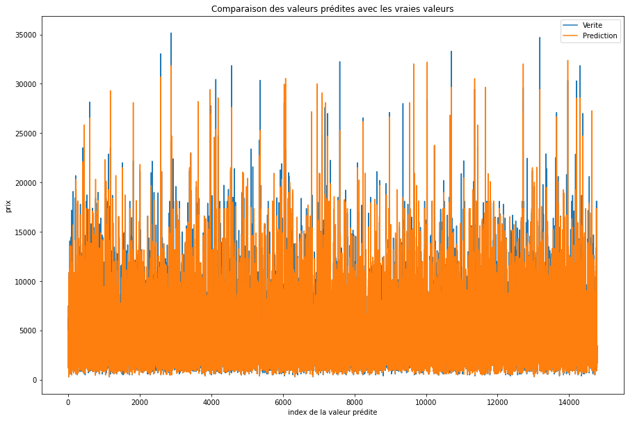

```python
df_pred[['Verite', 'Prediction']].plot(figsize=(15,10)
                                        , title='Comparaison des valeurs prédites avec les vraies valeurs'
                                        , xlabel='index de la valeur prédite'
                                        , ylabel='prix')
plt.show()
```

```python
df_copy.to_csv('../data/cleaned/ticket_data_cleaned.csv')
```